# Python Libraries for Data Analytics & Data Science

## Summary of Findings

- **Global Trends**: A steady increase in global average temperature was observed from 1961 to 2019, with a sharper rise after 2000.
- **Regional Differences**: Countries like Estonia and Slovenia experienced the highest temperature changes, while others had minimal changes.
- **Conclusion**: The results highlight the pressing need for global efforts to combat climate change, as its impacts are felt across regions and are becoming increasingly severe.

## Visualization: Top 10 Countries by Temperature Change

A bar chart visualizing the top 10 countries with the highest average temperature changes.

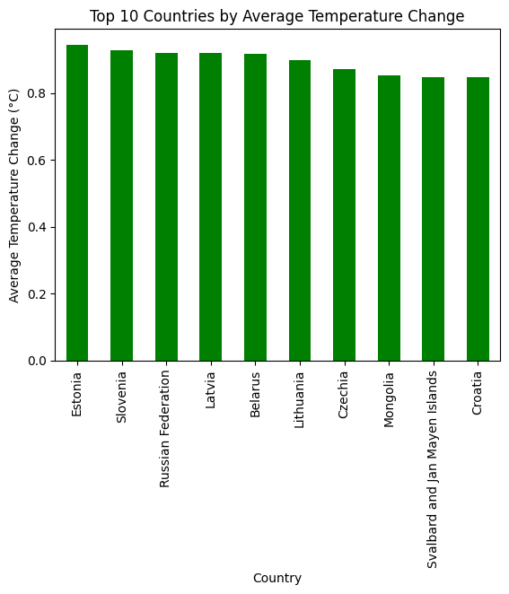

```python
top_10_countries.plot(kind='bar', color='green')
plt.title("Top 10 Countries by Average Temperature Change")
plt.xlabel("Country")
plt.ylabel("Average Temperature Change (°C)")
plt.show()
```

## Regional Comparison: Top and Bottom 10 Countries

This analysis highlights the countries with the highest and lowest average temperature changes, providing insights into regional impacts of climate change.

```python
top_10_countries = data.groupby('Country Name')['tem_change'].mean().sort_values(ascending=False).head(10)
bottom_10_countries = data.groupby('Country Name')['tem_change'].mean().sort_values(ascending=True).head(10)

print("Top 10 countries with highest average temperature change:")
print(top_10_countries)
print("\nBottom 10 countries with lowest average temperature change:")
print(bottom_10_countries)
```

```
Top 10 countries with highest average temperature change:
Country Name
Estonia                           0.945050
Slovenia                          0.928525
Russian Federation                0.919694
Latvia                            0.919304
Belarus                           0.918440
Lithuania                         0.897864
Czechia                           0.872155
Mongolia                          0.853729
Svalbard and Jan Mayen Islands    0.847881
Croatia                           0.846643
Name: tem_change, dtype: float64

Bottom 10 countries with lowest average temperature change:
Country Name
Antarctica                                      0.157508
Saint Pierre and Miquelon                       0.158051
South Georgia and the South Sandwich Islands    0.179172
Chile                                           0.184254
Pakistan                                        0.199237
Nepal                                           0.206085
India                                           0.216627
Bangladesh                                      0.227746
Norfolk Island                                  0.244759
British Virgin Islands                          0.247102
Name: tem_change, dtype: float64
```

## Future Temperature Prediction

Predicts global average temperature changes for 2020-2030 using historical trends.

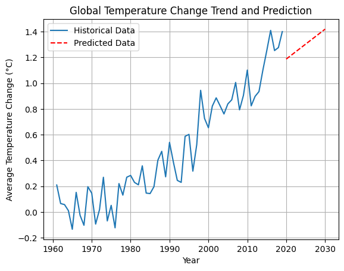

```python
from sklearn.linear_model import LinearRegression
import numpy as np

# Prepare data
years = np.array(global_temp_trend.index).reshape(-1, 1)
temps = np.array(global_temp_trend.values).reshape(-1, 1)

# Create and fit the model
model = LinearRegression()
model.fit(years, temps)

# Predict future temperature changes
future_years = np.array(range(2020, 2031)).reshape(-1, 1)
future_temps = model.predict(future_years)

# Plot the results
plt.plot(years, temps, label="Historical Data")
plt.plot(future_years, future_temps, label="Predicted Data", linestyle="--", color="red")
plt.title("Global Temperature Change Trend and Prediction")
plt.xlabel("Year")
plt.ylabel("Average Temperature Change (°C)")
plt.legend()
plt.grid(True)
plt.show()
```

## Global Average Temperature Change

The average global temperature change from 1961 to 2019 shows a steady increase, especially after 2000.

## Temperature Change in 2000 and 2010

Analyzing global temperature changes in 2000 and 2010 shows notable increases over time.

```python
year_2000 = data[data['year'] == 2000]['tem_change'].mean()
year_2010 = data[data['year'] == 2010]['tem_change'].mean()
print(f"Average temperature change in 2000: {year_2000:.2f}°C")
print(f"Average temperature change in 2010: {year_2010:.2f}°C")
```

```
Average temperature change in 2000: 0.65°C
Average temperature change in 2010: 1.10°C
```

## Top and Bottom 10 Countries

Highlights the top 10 and bottom 10 countries with the highest and lowest average temperature changes.

```python
top_10_countries = data.groupby('Country Name')['tem_change'].mean().sort_values(ascending=False).head(10)
bottom_10_countries = data.groupby('Country Name')['tem_change'].mean().sort_values(ascending=True).head(10)

print("Top 10 countries with highest average temperature change:")
print(top_10_countries)
print("\nBottom 10 countries with lowest average temperature change:")
print(bottom_10_countries)
```

```
Top 10 countries with highest average temperature change:
Country Name
Estonia                           0.945050
Slovenia                          0.928525
Russian Federation                0.919694
Latvia                            0.919304
Belarus                           0.918440
Lithuania                         0.897864
Czechia                           0.872155
Mongolia                          0.853729
Svalbard and Jan Mayen Islands    0.847881
Croatia                           0.846643
Name: tem_change, dtype: float64

Bottom 10 countries with lowest average temperature change:
Country Name
Antarctica                                      0.157508
Saint Pierre and Miquelon                       0.158051
South Georgia and the South Sandwich Islands    0.179172
Chile                                           0.184254
Pakistan                                        0.199237
Nepal                                           0.206085
India                                           0.216627
Bangladesh                                      0.227746
Norfolk Island                                  0.244759
British Virgin Islands                          0.247102
Name: tem_change, dtype: float64
```

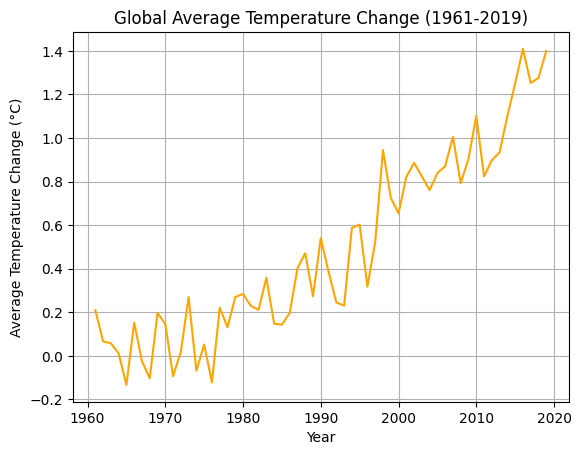

```python
global_temp_trend = data.groupby('year')['tem_change'].mean()
plt.plot(global_temp_trend.index, global_temp_trend.values, color='orange')
plt.title("Global Average Temperature Change (1961-2019)")
plt.xlabel("Year")
plt.ylabel("Average Temperature Change (°C)")
plt.grid(True)
plt.show()
```

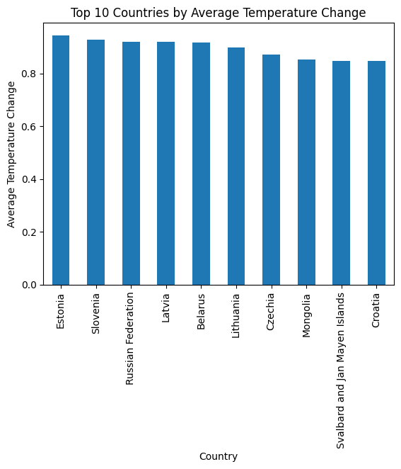

```python
country_avg_temp = data.groupby('Country Name')['tem_change'].mean().sort_values(ascending=False).head(10)
country_avg_temp.plot(kind='bar')
plt.title("Top 10 Countries by Average Temperature Change")
plt.xlabel("Country")
plt.ylabel("Average Temperature Change")
plt.show()
```

## Analysis 1: U.S. Temperature Change Trend

### Background

The United States, as one of the major contributors to global emissions, serves as an important case study for understanding climate change trends.

### Method

We filtered the dataset for the United States (`Country Code = 'USA'`) and plotted the temperature changes from 1961 to 2019.

### Result

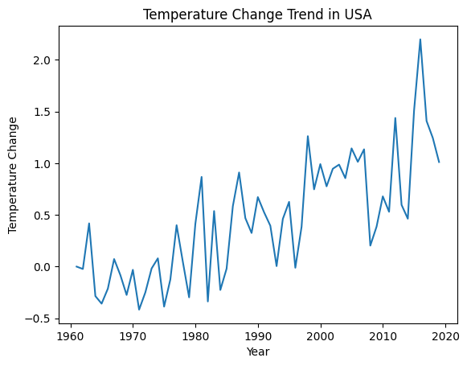

```python
import matplotlib.pyplot as plt

usa_data = data[data['Country Code'] == 'USA']
plt.plot(usa_data['year'], usa_data['tem_change'])
plt.title("Temperature Change Trend in USA")
plt.xlabel("Year")
plt.ylabel("Temperature Change")
plt.show()
```

```python
print(data['year'].min(), data['year'].max())
```

```
1961 2019
```

```python
print(data.isnull().sum())
```

```
Country Code    0
Country Name    0
year            0
tem_change      0
dtype: int64
```

## Data Cleaning

To ensure the dataset's quality and reliability, the following steps were taken:

1. **Handling Missing Values**:
   - For the `tem_change` column, missing values were filled with the column's mean value.
   - Rows with missing values in the `Country Code` column were removed.
2. **Removing Duplicates**:
   - Checked for duplicate rows and removed any found, ensuring data uniqueness.

After cleaning, the dataset contains 14,042 rows with no missing values in any column.

```python
data = data.dropna(subset=['Country Code'])
print(data.info())
```

```
<class 'pandas.core.frame.DataFrame'>
Index: 14042 entries, 0 to 16726
Data columns (total 4 columns):
 #   Column        Non-Null Count  Dtype
---  ------        --------------  -----
 0   Country Code  14042 non-null  object
 1   Country Name  14042 non-null  object
 2   year          14042 non-null  int64
 3   tem_change    14042 non-null  float64
dtypes: float64(1), int64(1), object(2)
memory usage: 548.5+ KB
None
```

```python
print(data.info())
```

```
<class 'pandas.core.frame.DataFrame'>
Index: 14042 entries, 0 to 16726
Data columns (total 4 columns):
 #   Column        Non-Null Count  Dtype
---  ------        --------------  -----
 0   Country Code  14042 non-null  object
 1   Country Name  14042 non-null  object
 2   year          14042 non-null  int64
 3   tem_change    14042 non-null  float64
dtypes: float64(1), int64(1), object(2)
memory usage: 548.5+ KB
None
```

```python
print(data.duplicated().sum())
data.drop_duplicates(inplace=True)
```

```
0
```

```python
data['tem_change'].fillna(data['tem_change'].mean(), inplace=True)
```

```python
print(data.isnull().sum())
```

```
Country Code    0
Country Name    0
year            0
tem_change      0
dtype: int64
```

## Data Loading

The dataset used in this analysis contains information about global climate change. It includes the following columns:

- `Country Code`: The code representing each country
- `Country Name`: The name of each country
- `year`: The year of observation
- `tem_change`: The temperature change (in degrees Celsius)

The dataset covers the period from 1961 to 2019 and initially consists of 16,756 rows. It provides insights into temperature changes globally over the years.

```python
import pandas as pd

file_path = "Temperature_change_Data.csv"
data = pd.read_csv(file_path)

print(data.info())
print(data.head())
```

```
<class 'pandas.core.frame.DataFrame'>
RangeIndex: 16756 entries, 0 to 16755
Data columns (total 4 columns):
 #   Column        Non-Null Count  Dtype
---  ------        --------------  -----
 0   Country Code  14042 non-null  object
 1   Country Name  16756 non-null  object
 2   year          16756 non-null  int64
 3   tem_change    14975 non-null  float64
dtypes: float64(1), int64(1), object(2)
memory usage: 523.8+ KB
None
  Country Code    Country Name  year  tem_change
0          AFG     Afghanistan  1961      -0.080
1          ALB         Albania  1961       0.631
2          DZA         Algeria  1961       0.186
3          ASM  American Samoa  1961      -0.014
4          AND         Andorra  1961       0.749
```

```python
import numpy as np
np.array([1, 2, 3])
```

```
array([1, 2, 3])
```

**numpy arrays** share many properties with Python lists

```python
a = np.array([1, 3, 2])
len(a)
a.sort()
a
```

```
array([1, 2, 3])
```

**arange** : In analogy with the list range() function, we can create array ranges in NumPy using np.arange()

```python
r = np.arange(17)
r
```

```
array([ 0,  1,  2,  3,  4,  5,  6,  7,  8,  9, 10, 11, 12, 13, 14, 15, 16])
```

Computations with numpy arrays are **much faster** than the corresponding operations with lists. Because NumPy itself is array-based, such computations **can also typically be expressed much more compactly**, without the need for loops or even comprehensions. In particular, NumPy arrays support vectorized operations, whereby we can (say) multiply every element in an array by a particular number all at once.

Import the numPy, Matplotlib and pandas libraries into the Python interpreter Then load the data set for the Nobel Laureates and show the summary stats for numeric fields

```python
[3 * i for i in r]   # This is Python can be expressed more compactly as
3 * a                # in numpy
```

```
array([3, 6, 9])
```

**timeit** - we can use the timeit library to compare execution speeds for normal Python and numpy structures. It Python let's do some heavy computation and time it:

```python
%%timeit
[i**2 for i in range(1000)]
```

```
49.5 μs ± 3.78 μs per loop (mean ± std. dev. of 7 runs, 10,000 loops each)
```

using numpy? -- You should see a huge difference in speeds!

```python
%%timeit
np.arange(1000)**2
```

```
2.25 μs ± 419 ns per loop (mean ± std. dev. of 7 runs, 100,000 loops each)
```

Numpy also provides support for **multi-dimensional arrays**

```python
a = np.array([[1, 2, 3], [4, 5, 6]])
a
```

```
array([[1, 2, 3],
       [4, 5, 6]])
```

# **Data Visualization with Matplotlib**

Matplotlib is a powerful visualization tool for Python that can do an absurdly large number of awesome things. The exact mechanics of getting Matplotlib plots to display varies widely depending on the exact details of your setup. The most explicit way to show plots, which works on most systems from the REPL, is to use the show() method:

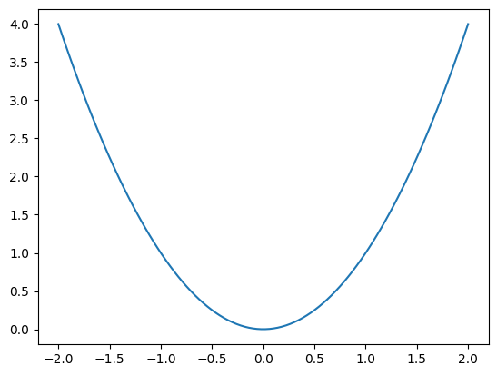

```python
import numpy as np
import matplotlib.pyplot as plt
x = np.linspace(-2, 2, 100)
fig, ax = plt.subplots(1, 1)
ax.plot(x, x*x)
plt.show()
%matplotlib inline
```

```python
import numpy as np
import matplotlib.pyplot as plt
import pandas as pd

nobel = pd.read_csv("laureates.csv")
nobel.describe()
```

[output not shown]

[output cut: 9 more lines]

[output not shown]

```python
nobel.head(10)
```

```python
nobel.info()
```

Let’s use array square brackets and a boolean criterion on the "surname" column to find record for the Physics noble laureate Feynman

```python
nobel[nobel["surname"] == "Feynman"]
```

```python
nobel[nobel["surname"] == "Feynman"].year
```

```python
(nobel["surname"] == "Feynman")[86]
```

```python
nobel.loc[nobel["surname"] == "Feynman", "year"]
```

Finding a record by substring.

```python
nobel.loc[nobel["firstname"].str.contains("Kip")]
```

Let's do sring search on a surname that produces multiple values

> > nobel.loc[nobel["surname"].str.contains("Feynman")] # fails because of too many NaNs Below shows the culprits

```python
nobel.loc[nobel["surname"].isnull()]
```

Here's how to filter NaNs - using by passing the option na=False to contains():

```python
nobel.loc[nobel["surname"].str.contains("Feynman", na=False)]
```

Although there’s only one Nobel laureate named “Feynman”, there are famously several named “Curie” Let's see dind Curies in the laureates.csv dataset.

```python
curies = nobel.loc[nobel["surname"].str.contains("Curie", na=False)]
curies
```

With the result assigned to the variable curies we can get the first name and surname for each Curie laureate as follows:

```python
curies[["firstname", "surname"]]
```

Marie Skłodowska-Curie is the only person to win a Nobel Prize for two different sciences. Let’s use pandas to see if there are any other multiple Nobel prize winners. We use groupby() to group the winners by name and then use the size() method to see how many there are:

```python
nobel.groupby(["firstname", "surname"]).size()
```

Let's add sort_values() to find any multiple laureates:

```python
nobel.groupby(["firstname", "surname"]).size().sort_values()
```

Even better is to use ID and groupby

```python
laureates = nobel.groupby(["id", "firstname", "surname"])
sizes = laureates.size()
sizes[sizes > 1]
```

One of pandas’ greatest strengths is its ability to deal with times and time series, so let’s start by taking a look at selecting dates. One way we can do this is by searching for laureates by exact birthday as a string

```python
nobel.loc[nobel["born"] == "1879-03-14"]
```

```python
nobel.loc[nobel["born"].str.contains("06-08", na=False)]
```

We can narrow down by restricting the results to Nobel laureates in Physics using the & operator to perform a logical and as follows

```python
nobel.loc[(nobel["born"].astype('string').str.contains("06-28")) & (nobel["category"] == "physics")]
```

```python
nobel.iloc[79]
```

Speaking of birthdates, the lifespans of Nobel laureates have been the subject of some scientific research over the years. An interesting exercise is to compute the lifespan of each nobel laurettes using the year of birth and year of death We will do this by creating a new lifespan colunn in the dataframe and using NumPy's magic time delta nobel["lifespan"] = (nobel["died"] - nobel["born"])/np.timedelta64(1, "Y")